# Simulation Exercise

Ehab Mohamed

25 October 2015

## Overview

The objective of this simulation excersise is to investigate the exponential distribution in R and compare it with the Central Limit Theorem. The distribution of averages of 40 exponentials will be investigated using thousand of simulations.

## Simulations

Lambda is definded below as well as the number of exponentials:

```r
set.seed(123456)
lambda <- 0.2
n <- 40
```

The 1000 averages of the 40 random exponentials are calculated as follows:

```r
mns = NULL
for (i in 1 : 1000) mns = c(mns, mean(rexp(n, lambda)))
```

The below figure shows the distribution of the thousand averages of the 40 random exponentials:

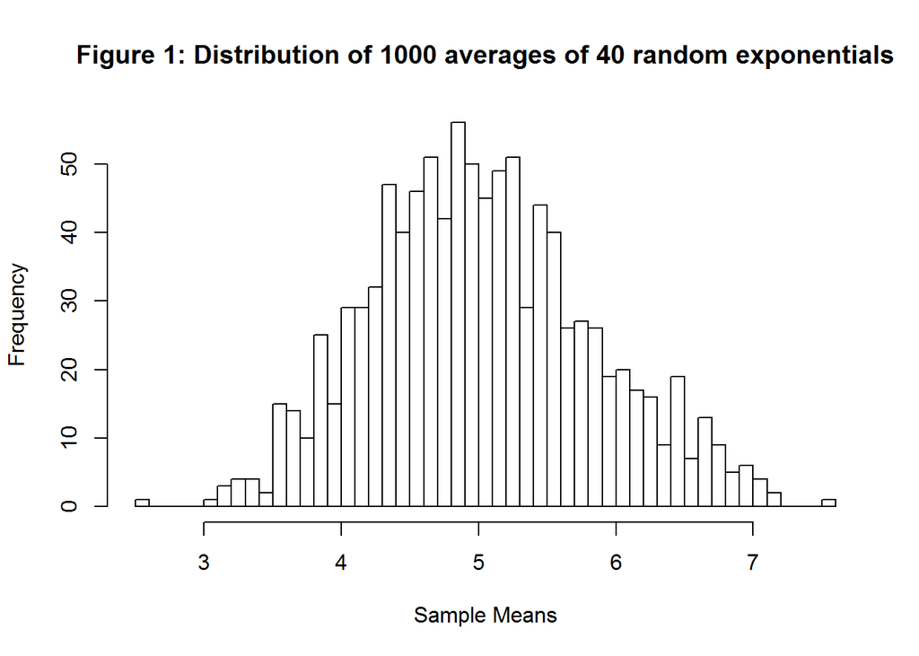

## Sample Mean versus Theoretical Mean

The theoretical mean as given can be calculated as follows:

```r
tm <- 1/lambda
tm
```

```
## [1] 5
```

The average sample mean is the average of the sample averages and can be calculated as follows:

```r
sm <- mean(mns)
sm
```

```
## [1] 5.022915
```

The results shows that the sample mean (which is 5.022915) is very close to the theoritical mean (which is 5).

The below figure shows the distribution of the thousand averages of the 40 random exponentials and highlights the theoretical and the average sample means:

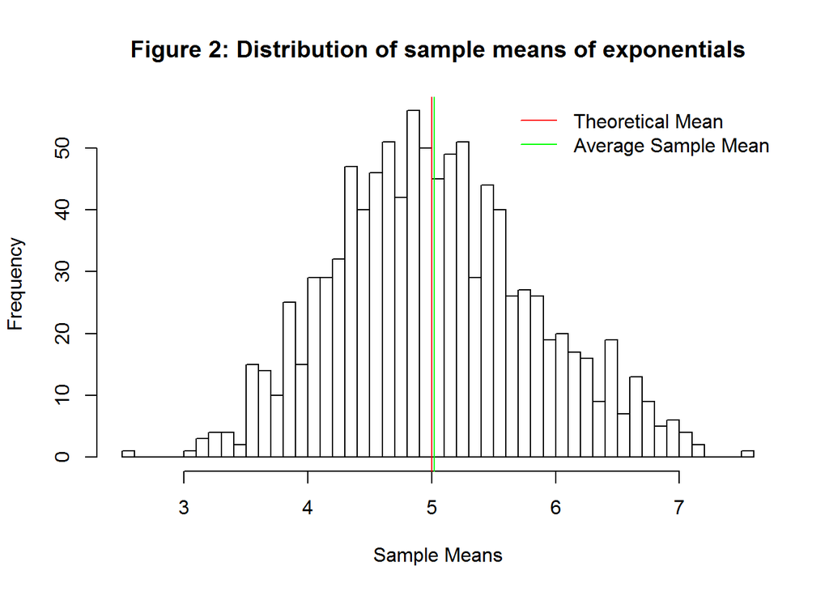

## Sample Variance versus Theoretical Variance

The theoretical variance can be calulated as follows:

```r
tv<-((1/lambda)^2)/n
tv
```

```
## [1] 0.625
```

The sample variance can be calulated as follows:

```r
sv <- var(mns)
sv
```

```
## [1] 0.6570391
```

## Distribution

This section focuses on the difference between the distribution of a large collection of random exponentials and the distribution of a large collection of averages of 40 exponentials.

The below figure shows the distribution of 1000 random exponentials:

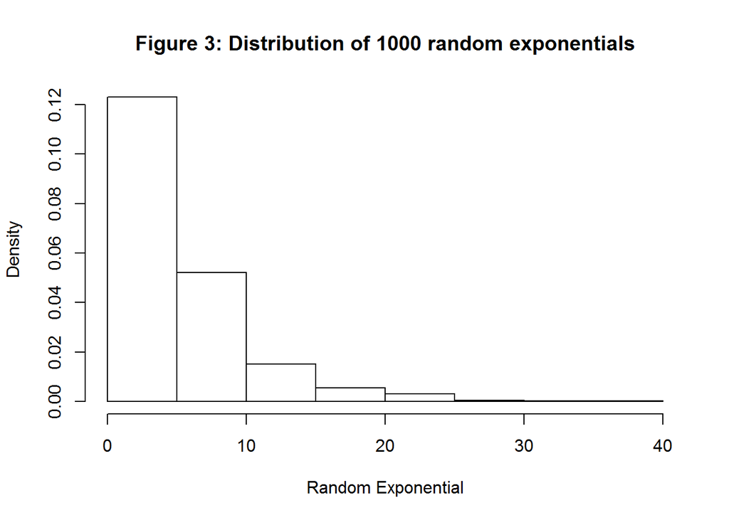

```r
rexp(1000, lambda)
```

The below figure shows that the distribution of the thousand averages of the 40 random exponentials is approximately normal:

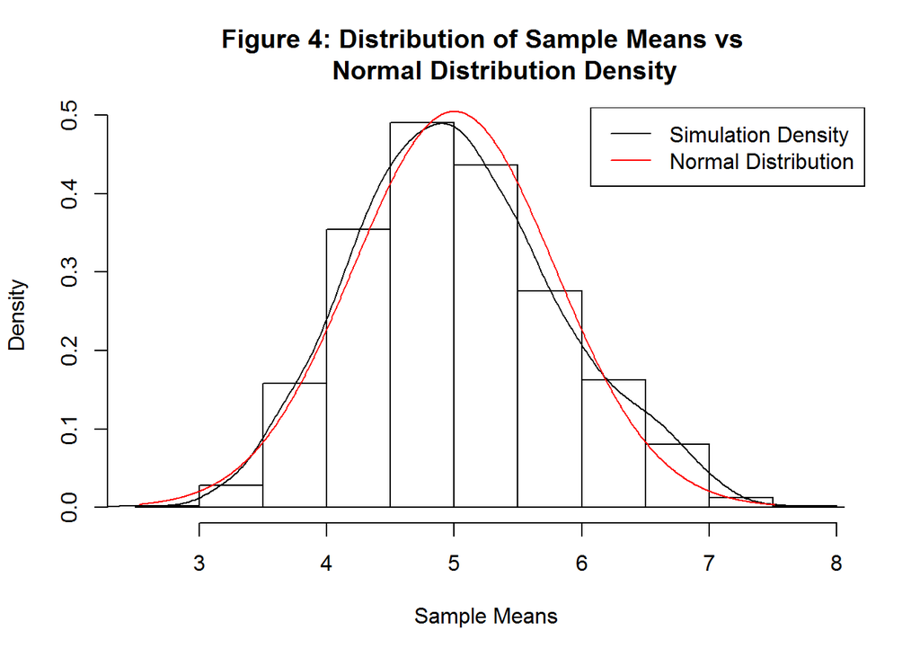

## Appendix

The source code of the illustrated figures are mentioned below:

Figure 1:

```r
hist(mns, freq=TRUE, breaks=50,
     main = "Figure 1: Distribution of 1000 averages of 40 random exponentials",
     xlab = "Sample Means")
```

Figure 2:

```r
hist(mns, freq=TRUE, breaks=50,
     main="Figure 2: Distribution of sample means of exponentials",
     xlab="Sample Means")

# Sample Mean - Green Line
abline(v=sm, col='green', lwd=1)

# Theoretical Mean - Red Line
abline(v=tm, col='red', lwd=1)

legend('topright', c("Theoretical Mean","Average Sample Mean"),
       col=c("red", "green"), lty=c(1,1), bty = "n")
```

Figure 3:

```r
hist(rexp(1000, lambda),  prob=T,
     main="Figure 3: Distribution of 1000 random exponentials",
     xlab="Random Exponential")
```

Figure 4:

```r
hist(mns,  prob=T,
     main="Figure 4: Distribution of Sample Means vs
     Normal Distribution Density",
     xlab="Sample Means")

# Density of the Simulated sample means
lines(density(mns))

# Density of the normal distribution
xfit <- seq(min(mns), max(mns), length=1000)
yfit <- dnorm(xfit, mean=1/lambda, sd=(1/lambda/sqrt(n)))
lines(xfit, yfit, pch=22, col="red", lty=1)

# Legend
legend('topright', c("Simulation Density", "Normal Distribution"),
       col=c("black", "red"), lty=c(1,1))
```